# Introduction

This dataset displays water quality data collected by Back Bay National Wildlife Refuge from 1989-2019. Samples collected once every two weeks from Back Bay and surrounding bodies of water (sites Bay, A, B, C, D) were measured by turbidity, pH, dissolved oxygen levels, salinity, and temperature. The purpose of this study was to ensure water quality standards were being met according to state regulations.

Citation:  
Back Bay National Wildlife Refuge. 2020. Water Quality Data. Virginia Beach, Virginia  
Virginia Department of Environmental Quality. Laws & Regulations. Virginia Department of Environmental Quality. https://www.deq.virginia.gov/laws-regulations

# Preprocessing

To prepare this data for analysis, I got rid of unnecessary columns such as extra temperature columns, who verified the data, and sample number. I also renamed some columns to be more understandable and to better suit my liking. I got rid of a row that I believe was mistakenly inputted as being sampled in 1899 and got rid of rows with NaN values or rows that lacked the needed data.

```python
import pandas as pd
water = pd.read_csv("BKB_WaterQualityData_2020084.csv")
water = water[water["Year"] > 1988]
water = water.drop(["Unit_Id", "Water Depth (m)", "Air Temp-Celsius", "Air Temp (?F)", "Time (24:00)", "Field_Tech", "DateVerified", "WhoVerified", "AirTemp (C)"], axis = 1)
water = water.rename(columns = {"Water Temp (?C)" : "Water Temp (C)", "pH (standard units)" : "pH"})
water = water.dropna()
water
```

|  | Site_Id | Read_Date | Salinity (ppt) | Dissolved Oxygen (mg/L) | pH | Secchi Depth (m) | Water Temp (C) | Year |
| --- | --- | --- | --- | --- | --- | --- | --- | --- |
| 0 | Bay | 1/3/1994 | 1.3 | 11.7 | 7.3 | 0.40 | 5.9 | 1994 |
| 1 | Bay | 1/31/1994 | 1.5 | 12.0 | 7.4 | 0.20 | 3.0 | 1994 |
| 2 | Bay | 2/7/1994 | 1.0 | 10.5 | 7.2 | 0.25 | 5.9 | 1994 |
| 3 | Bay | 2/23/1994 | 1.0 | 10.1 | 7.4 | 0.35 | 10.0 | 1994 |
| 4 | Bay | 2/28/1994 | 1.0 | 12.6 | 7.2 | 0.20 | 1.6 | 1994 |
| ... | ... | ... | ... | ... | ... | ... | ... | ... |
| 2361 | D | 10/11/2018 | 0.0 | 6.0 | 6.5 | 0.70 | 26.0 | 2018 |
| 2364 | D | 11/7/2018 | 0.0 | 6.9 | 6.5 | 0.90 | 20.0 | 2018 |
| 2366 | Bay | 10/11/2018 | 1.9 | 5.0 | 7.0 | 4.00 | 25.0 | 2018 |
| 2367 | Bay | 10/24/2018 | 0.0 | 9.0 | 7.0 | 0.30 | 18.0 | 2018 |
| 2368 | Bay | 10/28/2018 | 0.9 | 2.9 | 7.0 | 0.40 | 13.0 | 2018 |

1320 rows × 8 columns

Here is more processing to account for seasonal variation by grouping data by month.

```python
def month_convert(date):
    month_number = int(date.split('/')[0])
    if month_number == 1:
        month = "January"
    elif month_number == 2:
        month = "February"
    elif month_number == 3:
        month = "March"
    elif month_number == 4:
        month = "April"
    elif month_number == 5:
        month = "May"
    elif month_number == 6:
        month = "June"
    elif month_number == 7:
        month = "July"
    elif month_number == 8:
        month = "August"
    elif month_number == 9:
        month = "September"
    elif month_number == 10:
        month = "October"
    elif month_number == 11:
        month = "November"
    elif month_number == 12:
        month = "December"
    return month
water["Month"] = water["Read_Date"].apply(month_convert)
water.drop("Read_Date", axis = 1, inplace = True)
water
```

|  | Site_Id | Salinity (ppt) | Dissolved Oxygen (mg/L) | pH | Secchi Depth (m) | Water Temp (C) | Year | Month |
| --- | --- | --- | --- | --- | --- | --- | --- | --- |
| 0 | Bay | 1.3 | 11.7 | 7.3 | 0.40 | 5.9 | 1994 | January |
| 1 | Bay | 1.5 | 12.0 | 7.4 | 0.20 | 3.0 | 1994 | January |
| 2 | Bay | 1.0 | 10.5 | 7.2 | 0.25 | 5.9 | 1994 | February |
| 3 | Bay | 1.0 | 10.1 | 7.4 | 0.35 | 10.0 | 1994 | February |
| 4 | Bay | 1.0 | 12.6 | 7.2 | 0.20 | 1.6 | 1994 | February |
| ... | ... | ... | ... | ... | ... | ... | ... | ... |
| 2361 | D | 0.0 | 6.0 | 6.5 | 0.70 | 26.0 | 2018 | October |
| 2364 | D | 0.0 | 6.9 | 6.5 | 0.90 | 20.0 | 2018 | November |
| 2366 | Bay | 1.9 | 5.0 | 7.0 | 4.00 | 25.0 | 2018 | October |
| 2367 | Bay | 0.0 | 9.0 | 7.0 | 0.30 | 18.0 | 2018 | October |
| 2368 | Bay | 0.9 | 2.9 | 7.0 | 0.40 | 13.0 | 2018 | October |

1320 rows × 8 columns

Outlier Test - Salinity (ppt)

```python
IQR_sal = water["Salinity (ppt)"].quantile(0.75) - water["Salinity (ppt)"].quantile(0.25)
outlier_sal = water[(water["Salinity (ppt)"] < water["Salinity (ppt)"].quantile(0.25) - 1.5*IQR_sal) | (water["Salinity (ppt)"] > water["Salinity (ppt)"].quantile(0.75) + 1.5*IQR_sal)]
count = outlier_sal.groupby("Month").size()
months_order = ['January', 'February', 'March', 'April', 'May', 'June', 'July', 'August', 'September', 'October', 'November', 'December']
count.index = pd.Categorical(count.index, categories=months_order, ordered=True)
count = count.sort_index()
count
```

```
January       1
February      1
March         1
April         3
May           4
June         15
July         11
August       12
September     7
October      11
November      8
December      4
dtype: int64
```

```python
outlier_sal
```

|  | Site_Id | Salinity (ppt) | Dissolved Oxygen (mg/L) | pH | Secchi Depth (m) | Water Temp (C) | Year | Month |
| --- | --- | --- | --- | --- | --- | --- | --- | --- |
| 61 | Bay | 4.2 | 11.6 | 7.5 | 0.15 | 5.0 | 1990 | February |
| 68 | Bay | 4.1 | 10.8 | 7.0 | 0.25 | 11.0 | 1990 | April |
| 72 | Bay | 4.5 | 8.9 | 7.0 | 0.25 | 17.0 | 1990 | May |
| 79 | Bay | 3.8 | 7.9 | 7.0 | 0.35 | 26.0 | 1990 | June |
| 81 | Bay | 4.2 | 7.5 | 7.5 | 0.30 | 26.0 | 1990 | July |
| ... | ... | ... | ... | ... | ... | ... | ... | ... |
| 813 | Bay | 4.0 | 3.7 | 7.0 | 0.50 | 27.0 | 2003 | September |
| 867 | B | 4.0 | 5.7 | 7.5 | 0.20 | 4.0 | 2004 | December |
| 1159 | Bay | 8.0 | 0.1 | 7.0 | 0.40 | 18.0 | 2006 | October |
| 1383 | Bay | 4.0 | 6.2 | 7.0 | 0.50 | 24.5 | 2008 | June |
| 2309 | Bay | 9.0 | 4.2 | 8.0 | 0.40 | 24.0 | 2019 | June |

78 rows × 8 columns

Outlier Test - Dissolved Oxygen (mg/L)

```python
IQR_DO = water["Dissolved Oxygen (mg/L)"].quantile(0.75) - water["Dissolved Oxygen (mg/L)"].quantile(0.25)
outlier_DO = water[(water["Dissolved Oxygen (mg/L)"] < water["Dissolved Oxygen (mg/L)"].quantile(0.25) - 1.5*IQR_DO) | (water["Dissolved Oxygen (mg/L)"] > water["Dissolved Oxygen (mg/L)"].quantile(0.75) + 1.5*IQR_DO)]
outlier_DO
```

|  | Site_Id | Salinity (ppt) | Dissolved Oxygen (mg/L) | pH | Secchi Depth (m) | Water Temp (C) | Year | Month |
| --- | --- | --- | --- | --- | --- | --- | --- | --- |
| 133 | Bay | 1.4 | 15.1 | 8.0 | 0.2 | 2.0 | 1991 | December |

Outlier Test - pH

```python
IQR_pH = water["pH"].quantile(0.75) - water["pH"].quantile(0.25)
outlier_pH = water[(water["pH"] < water["pH"].quantile(0.25) - 1.5*IQR_pH) | (water["pH"] > water["pH"].quantile(0.75) + 1.5*IQR_pH)]
count = outlier_pH.groupby("Month").size()
months_order = ['January', 'February', 'March', 'April', 'May', 'June', 'July', 'August', 'September', 'October', 'November', 'December']
count.index = pd.Categorical(count.index, categories=months_order, ordered=True)
count = count.sort_index()
count
```

```
January      2
February     4
March        2
April        3
May          3
June         5
July         2
August       7
September    2
November     3
December     2
dtype: int64
```

```python
outlier_pH
```

|  | Site_Id | Salinity (ppt) | Dissolved Oxygen (mg/L) | pH | Secchi Depth (m) | Water Temp (C) | Year | Month |
| --- | --- | --- | --- | --- | --- | --- | --- | --- |
| 15 | Bay | 1.0 | 10.80 | 9.1 | 0.05 | 21.7 | 1994 | May |
| 22 | Bay | 2.0 | 11.00 | 9.4 | 0.50 | 30.5 | 1994 | June |
| 23 | Bay | 2.0 | 10.70 | 9.2 | 0.45 | 29.0 | 1994 | August |
| 24 | Bay | 2.0 | 10.20 | 9.2 | 0.40 | 22.0 | 1994 | August |
| 26 | Bay | 2.0 | 9.10 | 9.1 | 0.45 | 27.0 | 1994 | August |
| 27 | Bay | 2.3 | 9.80 | 9.3 | 0.45 | 27.0 | 1994 | August |
| 250 | Bay | 4.5 | 10.40 | 9.2 | 0.30 | 24.5 | 1995 | September |
| 381 | Bay | 1.8 | 1.80 | 9.5 | 0.35 | 27.0 | 1999 | August |
| 382 | Bay | 3.0 | 7.00 | 9.2 | 0.40 | 28.0 | 1999 | August |
| 388 | Bay | 1.0 | 8.70 | 9.1 | 0.50 | 11.0 | 1999 | December |
| 417 | B | 1.5 | 7.60 | 9.7 | 4.00 | 30.0 | 2000 | May |
| 441 | C | 1.0 | 8.20 | 9.5 | 0.40 | 28.0 | 2000 | June |
| 475 | D | 0.0 | 10.00 | 9.3 | 1.10 | 7.0 | 2000 | December |
| 481 | Bay | 1.5 | 7.60 | 9.1 | 0.30 | 18.0 | 2000 | April |
| 495 | Bay | 1.0 | 4.80 | 9.2 | 0.30 | 16.0 | 2000 | November |
| 496 | Bay | 1.0 | 7.80 | 9.9 | 0.40 | 13.0 | 2000 | November |
| 507 | A | 1.0 | 2.50 | 9.1 | 0.20 | 22.0 | 2001 | May |
| 512 | A | 1.5 | 4.90 | 9.2 | 0.50 | 26.0 | 2001 | July |
| 515 | A | 3.0 | 3.00 | 0.3 | 0.35 | 26.0 | 2001 | September |
| 575 | D | 0.0 | 4.10 | 9.3 | 0.80 | 19.5 | 2001 | April |
| 591 | Bay | 1.0 | 8.10 | 9.2 | 0.36 | 7.0 | 2001 | January |
| 592 | Bay | 1.0 | 9.00 | 9.3 | 0.10 | 8.0 | 2001 | January |
| 594 | Bay | 1.0 | 9.20 | 9.1 | 0.20 | 11.0 | 2001 | February |
| 595 | Bay | 1.2 | 9.25 | 9.2 | 0.35 | 14.0 | 2001 | March |
| 596 | Bay | 1.0 | 9.90 | 9.4 | 0.25 | 10.0 | 2001 | March |
| 598 | Bay | 2.0 | 6.40 | 9.3 | 0.30 | 20.0 | 2001 | April |
| 601 | Bay | 2.0 | 4.35 | 9.2 | 0.40 | 23.0 | 2001 | June |
| 604 | Bay | 3.0 | 7.20 | 9.8 | 0.30 | 23.0 | 2001 | July |
| 605 | Bay | 3.0 | 4.10 | 9.1 | 0.40 | 30.0 | 2001 | August |
| 611 | Bay | 3.0 | 5.50 | 9.5 | 0.25 | 13.0 | 2001 | November |
| 680 | D | 0.0 | 8.30 | 9.6 | 1.30 | 11.0 | 2002 | February |
| 702 | Bay | 3.0 | 5.70 | 9.9 | 0.10 | 12.0 | 2002 | February |
| 703 | Bay | 3.0 | 7.60 | 9.2 | 0.30 | 11.0 | 2002 | February |
| 749 | B | 0.0 | 8.50 | 9.5 | 0.10 | 25.1 | 2003 | June |
| 2217 | A | 0.1 | 4.70 | 4.8 | 0.50 | 27.0 | 2018 | June |

Outlier Test - Secchi Depth (m)

```python
IQR_secchi = water["Secchi Depth (m)"].quantile(0.75) - water["Secchi Depth (m)"].quantile(0.25)
outlier_secchi = water[(water["Secchi Depth (m)"] < water["Secchi Depth (m)"].quantile(0.25) - 1.5*IQR_secchi) | (water["Secchi Depth (m)"] > water["Secchi Depth (m)"].quantile(0.75) + 1.5*IQR_secchi)]
count = outlier_secchi.groupby("Month").size()
months_order = ['January', 'February', 'March', 'April', 'May', 'June', 'July', 'August', 'September', 'October', 'November', 'December']
count.index = pd.Categorical(count.index, categories=months_order, ordered=True)
count = count.sort_index()
count
```

```
January      11
February     13
March         9
April         3
May           4
June          1
July          3
August        2
September     2
October       7
November      7
December     12
dtype: int64
```

```python
outlier_secchi
```

|  | Site_Id | Salinity (ppt) | Dissolved Oxygen (mg/L) | pH | Secchi Depth (m) | Water Temp (C) | Year | Month |
| --- | --- | --- | --- | --- | --- | --- | --- | --- |
| 301 | Bay | 1.5 | 10.90 | 6.6 | 2.50 | 10.1 | 1997 | February |
| 362 | C | 1.0 | 2.40 | 8.0 | 5.80 | 34.0 | 1999 | September |
| 371 | D | 0.0 | 1.50 | 7.4 | 1.75 | 34.5 | 1999 | September |
| 375 | D | 0.0 | 6.50 | 8.0 | 1.05 | 15.0 | 1999 | November |
| 378 | D | 0.0 | 8.25 | 8.0 | 1.10 | 5.0 | 1999 | December |
| ... | ... | ... | ... | ... | ... | ... | ... | ... |
| 2205 | D | 0.0 | 9.90 | 6.5 | 1.30 | 7.0 | 2017 | December |
| 2215 | A | 0.1 | 4.00 | 6.5 | 5.50 | 26.0 | 2018 | May |
| 2241 | D | 0.0 | 10.00 | 6.5 | 1.60 | 4.0 | 2018 | January |
| 2242 | D | 0.0 | 9.50 | 6.5 | 1.30 | 6.0 | 2018 | February |
| 2366 | Bay | 1.9 | 5.00 | 7.0 | 4.00 | 25.0 | 2018 | October |

74 rows × 8 columns

Outlier Test - Water Temp (C)

```python
IQR_temp = water["Water Temp (C)"].quantile(0.75) - water["Water Temp (C)"].quantile(0.25)
outlier_temp = water[(water["Water Temp (C)"] < water["Water Temp (C)"].quantile(0.25) - 1.5*IQR_temp) | (water["Water Temp (C)"] > water["Water Temp (C)"].quantile(0.75) + 1.5*IQR_temp)]
outlier_temp
```

|  | Site_Id | Salinity (ppt) | Dissolved Oxygen (mg/L) | pH | Secchi Depth (m) | Water Temp (C) | Year | Month |
| --- | --- | --- | --- | --- | --- | --- | --- | --- |
| 701 | Bay | 3.0 | 9.0 | 9.0 | 0.3 | 59.0 | 2002 | January |
| 822 | A | 1.0 | 7.0 | 7.0 | 0.8 | 60.0 | 2004 | February |
| 1038 | Bay | 0.0 | 5.0 | 6.5 | 0.1 | 74.0 | 2005 | September |
| 1232 | D | 0.0 | 7.6 | 5.0 | 1.2 | 54.0 | 2007 | January |

# Summary Data Analysis

Below is a graph of the distribution of the number of samples taken from each site.

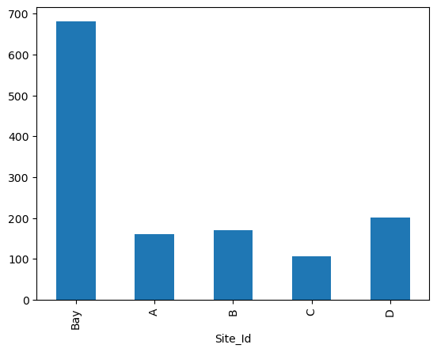

```python
import matplotlib as plt
counts = water["Site_Id"].value_counts()
counts = counts.loc[['Bay', 'A', 'B', 'C', 'D']]
counts.plot(kind = "bar")
plt.pyplot.show()
```

Below are the averages of each quantitative column for each site over all the years in which data was collected.

```python
filter = water.drop(["Month", "Year"], axis = 1)
averages = filter.groupby("Site_Id").mean()
averages = averages.loc[['Bay', 'A', 'B', 'C', 'D']]
averages
```

| Site_Id | Salinity (ppt) | Dissolved Oxygen (mg/L) | pH | Secchi Depth (m) | Water Temp (C) |
| --- | --- | --- | --- | --- | --- |
| Bay | 1.494714 | 7.677107 | 7.382452 | 0.405044 | 17.422482 |
| A | 0.345875 | 5.372813 | 6.936875 | 0.608437 | 19.500000 |
| B | 0.440588 | 5.383294 | 7.307647 | 0.304882 | 18.501176 |
| C | 0.499159 | 5.591589 | 7.318692 | 0.480935 | 18.336449 |
| D | 0.088317 | 6.386139 | 6.726733 | 0.893218 | 18.272772 |

Here are the averages of each quantitative value for the site Bay grouped by month for the years 1989-2019.

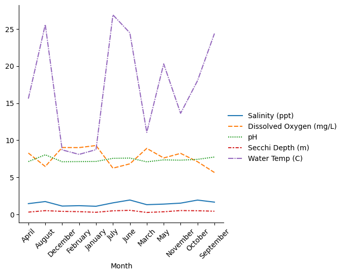

```python
import numpy as np
import seaborn as sns
import matplotlib.pyplot as plt
site_Bay = water[water["Site_Id"] == "Bay"]
numeric_columns = site_Bay.select_dtypes(include = [np.number]).columns.tolist()
month_dict = {1: "January", 2: "February", 3: "March", 4: "April", 5: "May", 6: "June", 7: "July", 8: "August", 9: "September", 10: "October", 11: "November", 12: "December"}
water["Month"].replace(month_dict, inplace = True)
averages = site_Bay.groupby("Month")[numeric_columns].mean()
averages = averages.drop("Year", axis = 1)
averages
graph = sns.relplot(data = averages, kind = "line")
graph.set_xticklabels(rotation = 45)
graph
```

```python
averages
```

| Month | Salinity (ppt) | Dissolved Oxygen (mg/L) | pH | Secchi Depth (m) | Water Temp (C) |
| --- | --- | --- | --- | --- | --- |
| April | 1.442687 | 8.267910 | 7.114179 | 0.298060 | 15.613433 |
| August | 1.722203 | 6.455085 | 8.030508 | 0.495085 | 25.600000 |
| December | 1.115217 | 9.014130 | 7.095652 | 0.399783 | 8.693696 |
| February | 1.166071 | 9.002679 | 7.116071 | 0.360357 | 8.085714 |
| January | 1.088000 | 9.283000 | 7.136000 | 0.274600 | 8.728000 |
| July | 1.547273 | 6.228182 | 7.555455 | 0.473273 | 26.909091 |
| June | 1.930769 | 6.813077 | 7.587692 | 0.539923 | 24.486154 |
| March | 1.301786 | 8.899107 | 7.083929 | 0.254018 | 11.051786 |
| May | 1.380000 | 7.603770 | 7.344262 | 0.344344 | 20.303279 |
| November | 1.508929 | 8.223750 | 7.302679 | 0.507321 | 13.626786 |
| October | 1.921429 | 7.099107 | 7.419643 | 0.482143 | 18.030357 |
| September | 1.645370 | 5.642593 | 7.729630 | 0.418333 | 24.394444 |

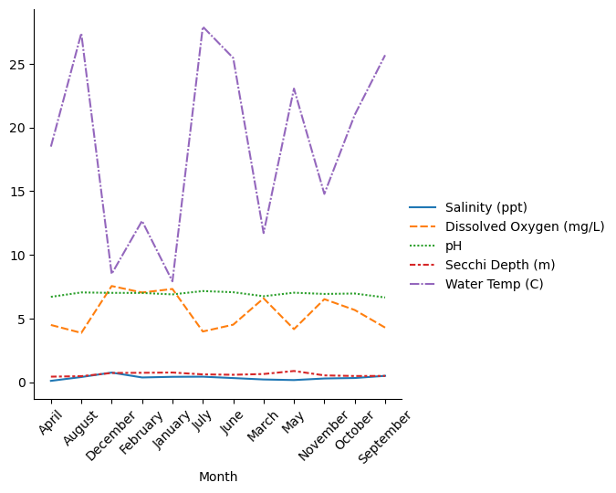

```python
import numpy as np
import matplotlib.pyplot as plt
site_Bay = water[water["Site_Id"] == "A"]
numeric_columns = site_Bay.select_dtypes(include=[np.number]).columns.tolist()
averages = site_Bay.groupby("Month")[numeric_columns].mean()
averages = averages.drop('Year', axis=1)
graph = sns.relplot(data = averages, kind = "line")
graph.set_xticklabels(rotation = 45)
graph
```

```python
averages
```

| Month | Salinity (ppt) | Dissolved Oxygen (mg/L) | pH | Secchi Depth (m) | Water Temp (C) |
| --- | --- | --- | --- | --- | --- |
| April | 0.100000 | 4.490000 | 6.700000 | 0.430000 | 18.500000 |
| August | 0.400000 | 3.866667 | 7.046667 | 0.466667 | 27.400000 |
| December | 0.750000 | 7.550000 | 7.012500 | 0.718750 | 8.500000 |
| February | 0.366667 | 7.040000 | 7.006667 | 0.733333 | 12.666667 |
| January | 0.416667 | 7.316667 | 6.891667 | 0.754167 | 7.916667 |
| July | 0.426923 | 3.976923 | 7.153846 | 0.607692 | 27.923077 |
| June | 0.318750 | 4.512500 | 7.062500 | 0.578125 | 25.468750 |
| March | 0.208333 | 6.583333 | 6.750000 | 0.637500 | 11.708333 |
| May | 0.162500 | 4.162500 | 7.025000 | 0.875000 | 23.062500 |
| November | 0.285714 | 6.517857 | 6.928571 | 0.528571 | 14.785714 |
| October | 0.323077 | 5.665385 | 6.961538 | 0.480769 | 21.000000 |
| September | 0.493125 | 4.284375 | 6.650000 | 0.487500 | 25.687500 |

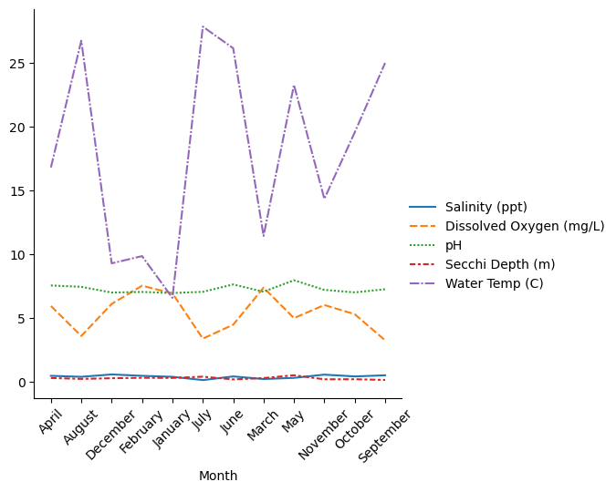

```python
import numpy as np
import matplotlib.pyplot as plt
site_Bay = water[water["Site_Id"] == "B"]
numeric_columns = site_Bay.select_dtypes(include=[np.number]).columns.tolist()
averages = site_Bay.groupby("Month")[numeric_columns].mean()
averages = averages.drop('Year', axis=1)
graph = sns.relplot(data = averages, kind = "line")
graph.set_xticklabels(rotation = 45)
graph
```

```python
averages
```

| Month | Salinity (ppt) | Dissolved Oxygen (mg/L) | pH | Secchi Depth (m) | Water Temp (C) |
| --- | --- | --- | --- | --- | --- |
| April | 0.500000 | 5.975000 | 7.583333 | 0.329167 | 16.833333 |
| August | 0.423077 | 3.623077 | 7.476923 | 0.258462 | 26.769231 |
| December | 0.609091 | 6.136364 | 7.027273 | 0.311818 | 9.318182 |
| February | 0.500000 | 7.561538 | 7.076923 | 0.346154 | 9.884615 |
| January | 0.423077 | 6.969231 | 6.992308 | 0.334615 | 6.615385 |
| July | 0.166667 | 3.416667 | 7.083333 | 0.433333 | 27.875000 |
| June | 0.452941 | 4.505882 | 7.664706 | 0.220588 | 26.182353 |
| March | 0.250000 | 7.414286 | 7.092857 | 0.321429 | 11.464286 |
| May | 0.340000 | 5.024000 | 7.993333 | 0.544000 | 23.306667 |
| November | 0.593750 | 6.050000 | 7.237500 | 0.228125 | 14.375000 |
| October | 0.452941 | 5.329412 | 7.041176 | 0.232353 | 19.588235 |
| September | 0.541176 | 3.282353 | 7.288235 | 0.178235 | 25.029412 |

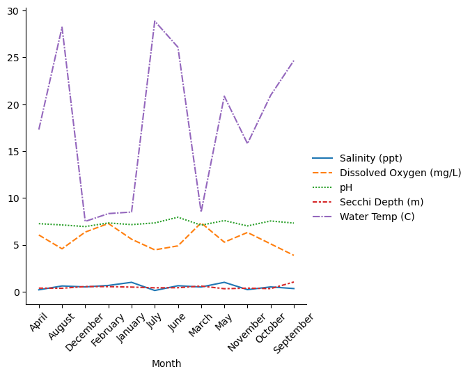

```python
import numpy as np
import matplotlib.pyplot as plt
site_Bay = water[water["Site_Id"] == "C"]
numeric_columns = site_Bay.select_dtypes(include=[np.number]).columns.tolist()
averages = site_Bay.groupby("Month")[numeric_columns].mean()
averages = averages.drop('Year', axis=1)
graph =sns.relplot(data = averages, kind = "line")
plt.xticks(rotation=45)
graph
```

```python
averages
```

| Month | Salinity (ppt) | Dissolved Oxygen (mg/L) | pH | Secchi Depth (m) | Water Temp (C) |
| --- | --- | --- | --- | --- | --- |
| April | 0.200000 | 6.050000 | 7.260000 | 0.377000 | 17.300000 |
| August | 0.611111 | 4.577778 | 7.122222 | 0.366667 | 28.222222 |
| December | 0.510000 | 6.360000 | 6.950000 | 0.547000 | 7.500000 |
| February | 0.666667 | 7.277778 | 7.333333 | 0.538889 | 8.333333 |
| January | 1.000000 | 5.600000 | 7.160000 | 0.490000 | 8.500000 |
| July | 0.126250 | 4.462500 | 7.337500 | 0.412500 | 28.875000 |
| June | 0.636364 | 4.890909 | 7.945455 | 0.422727 | 26.090909 |
| March | 0.500000 | 7.350000 | 7.100000 | 0.600000 | 8.500000 |
| May | 1.000000 | 5.285714 | 7.585714 | 0.317143 | 20.857143 |
| November | 0.220000 | 6.320000 | 7.020000 | 0.375000 | 15.800000 |
| October | 0.509091 | 5.100000 | 7.545455 | 0.327273 | 20.954545 |
| September | 0.333333 | 3.877778 | 7.322222 | 1.033333 | 24.666667 |

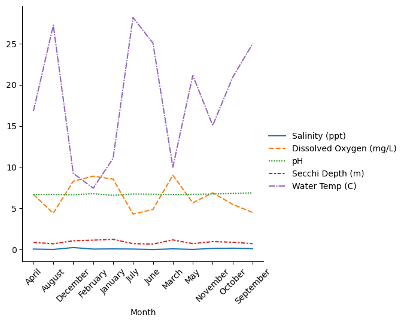

```python
import numpy as np
import matplotlib as plt
site_Bay = water[water["Site_Id"] == "D"]
numeric_columns = site_Bay.select_dtypes(include=[np.number]).columns.tolist()
averages = site_Bay.groupby("Month")[numeric_columns].mean()
averages = averages.drop('Year', axis=1)
graph = sns.relplot(data = averages, kind = "line")
graph.set_xticklabels(rotation = 45)
graph
```

```python
averages
```

| Month | Salinity (ppt) | Dissolved Oxygen (mg/L) | pH | Secchi Depth (m) | Water Temp (C) |
| --- | --- | --- | --- | --- | --- |
| April | 0.055556 | 6.677778 | 6.688889 | 0.866667 | 16.805556 |
| August | 0.011765 | 4.411765 | 6.682353 | 0.701765 | 27.235294 |
| December | 0.238095 | 8.292857 | 6.652381 | 1.061905 | 9.261905 |
| February | 0.055556 | 8.905556 | 6.777778 | 1.138889 | 7.444444 |
| January | 0.076923 | 8.553846 | 6.584615 | 1.238462 | 11.076923 |
| July | 0.058824 | 4.305882 | 6.741176 | 0.711765 | 28.176471 |
| June | 0.000000 | 4.866667 | 6.713333 | 0.666667 | 25.066667 |
| March | 0.083333 | 9.025000 | 6.666667 | 1.166667 | 10.000000 |
| May | 0.015000 | 5.668750 | 6.706250 | 0.712500 | 21.150000 |
| November | 0.133333 | 6.886667 | 6.733333 | 0.960000 | 15.066667 |
| October | 0.161905 | 5.483333 | 6.819048 | 0.885714 | 20.904762 |
| September | 0.105263 | 4.500000 | 6.878947 | 0.710526 | 24.984211 |

Here is a line graph showing the average salinity per year in ppt from the years 1989-2019, color coded by site. The second graph compares the mean salinities in ppt of each site. Because salinity stays relatively constant throughout a given year, the data is not grouped by month in any way.

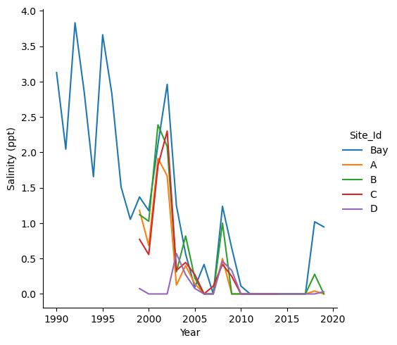

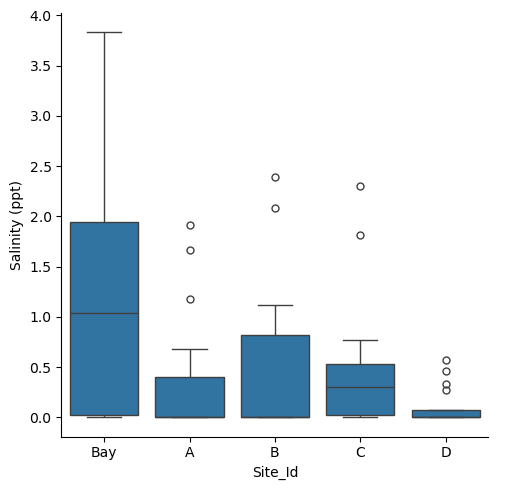

```python
import seaborn as sns
average_salinity = water.groupby(['Year', 'Site_Id'])['Salinity (ppt)'].mean().reset_index()
sns.relplot(data = average_salinity, x = "Year", y = "Salinity (ppt)", kind = "line", hue = "Site_Id")
sns.catplot(data = average_salinity, x = "Site_Id", y = "Salinity (ppt)", kind = "box")
```

Here is a graph showing trends in the dissolved oxygen levels in mg/L from the years 1999-2019, color coded by site. Because dissolved oxygen varies seasonally, the graphs are grouped by month. This second graph compares the mean levels of dissolved oxygen in mg/L for all five sites. The third graph shows dissolved oxygen levels for site Bay from 1989-2019. This is a separate graph because from 1989-1998, the dissolved oxygen levels were abnormally, but consistently, high, and then in 1999 they dropped down and remained relatively in the same lower range.

[output not shown]

[output cut: 96 more lines]

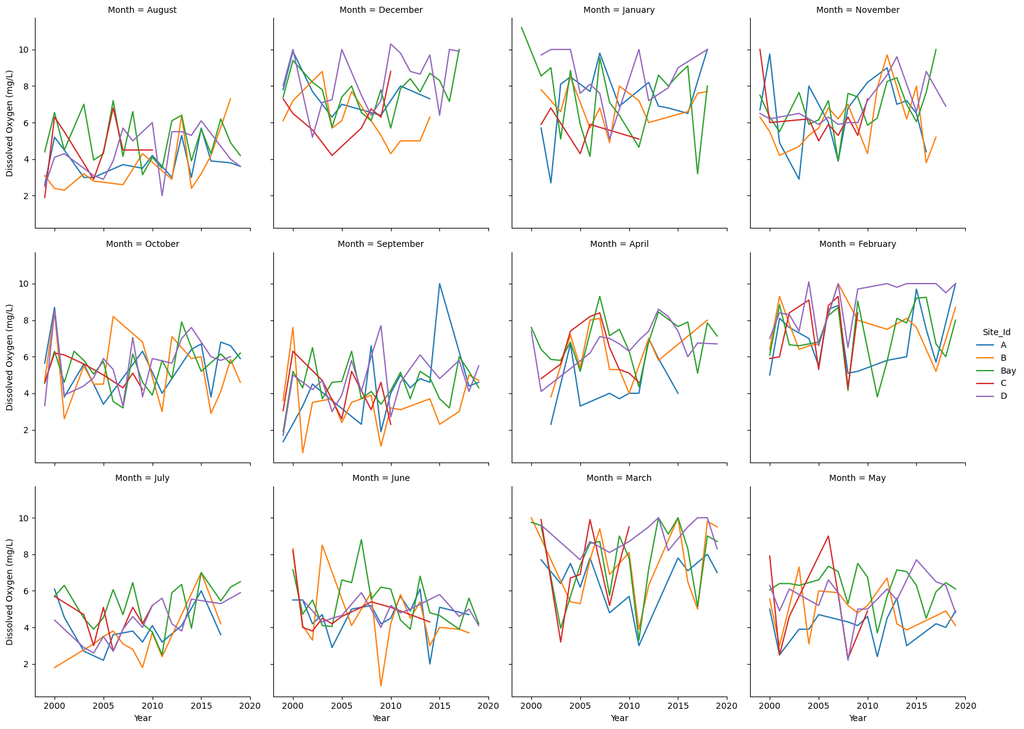

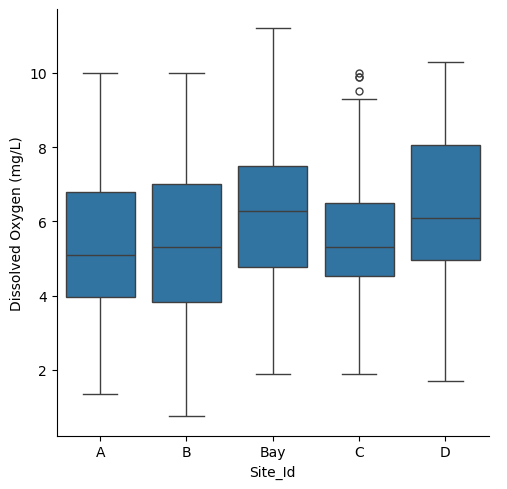

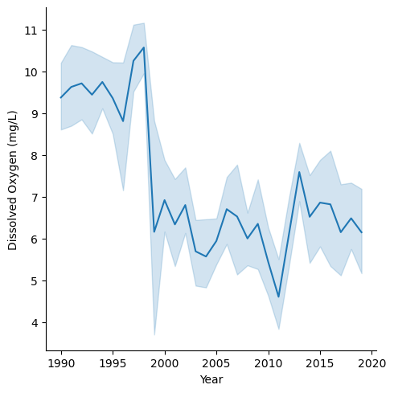

```python
import seaborn as sns
average_DO = water.groupby(["Year", "Month", "Site_Id"])["Dissolved Oxygen (mg/L)"].mean().reset_index()
bay = average_DO[average_DO["Site_Id"] == "Bay"]
average_DO = average_DO[average_DO["Year"] > 1998]
sns.relplot(data = average_DO, x = "Year", y = "Dissolved Oxygen (mg/L)", kind = "line", hue = "Site_Id", col = "Month", col_wrap = 4, height = 4)
sns.catplot(data = average_DO, x = "Site_Id", y = "Dissolved Oxygen (mg/L)", kind = "box")
sns.relplot(data = bay, x = "Year", y = "Dissolved Oxygen (mg/L)", kind = "line")
```

Here is a graph showing the average pH each year from the years 1989-2019, color coded by site. The second graph compares the mean pH of each site. Because pH stays relatively constant throughout a given year, the data is not grouped by month in any way.

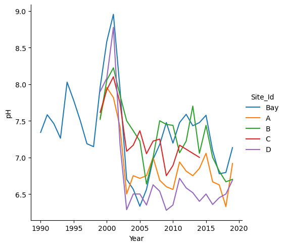

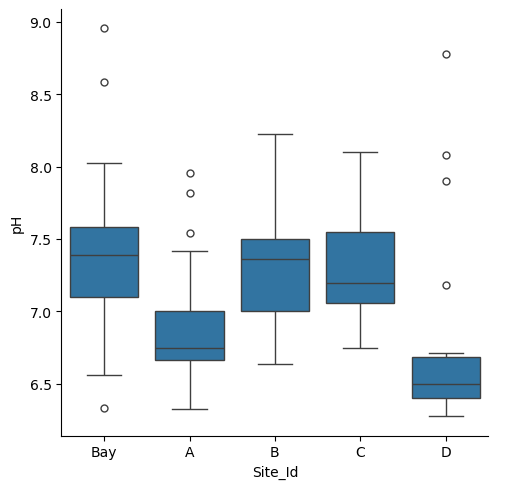

```python
import seaborn as sns
average_pH = water.groupby(["Year", "Site_Id"])["pH"].mean().reset_index()
sns.relplot(data = average_pH, x = "Year", y = "pH", kind = "line", hue = "Site_Id")
sns.catplot(data = average_pH, x = "Site_Id", y = "pH", kind = "box")
```

Here is a graph showing the average Secchi depth in meters from the years 1989-2019, color coded by site. Secchi depth is a measurement of water transparency determined by how deep sunlight can penetrate the water. A shallow Secchi depth indicates cloudy waters. This is caused by a larger abundance of phytoplankton, which means the environment is healthy. Because Secchi depth stays relatively constant throughout a given year, the data is not grouped by month in any way.

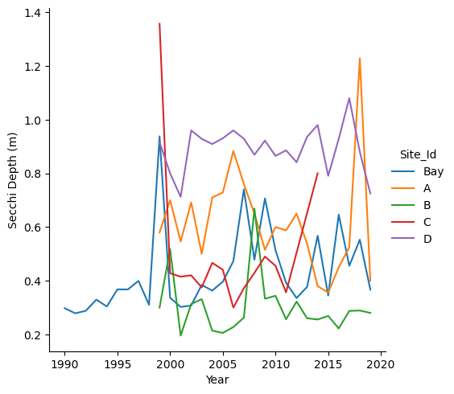

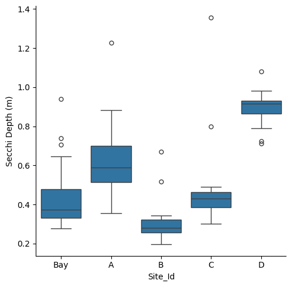

```python
import seaborn as sns
average_secchi = water.groupby(["Year", "Site_Id"])["Secchi Depth (m)"].mean().reset_index()
sns.relplot(data = average_secchi, x = "Year", y = "Secchi Depth (m)", kind = "line", hue = "Site_Id")
sns.catplot(data = average_secchi, x = "Site_Id", y = "Secchi Depth (m)", kind = "box")
```

[output not shown]

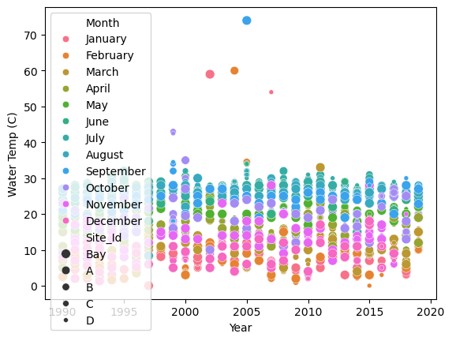

```python
import seaborn as sns
sns.scatterplot(data = water, x = "Year", y = "Water Temp (C)", hue = "Month", size = "Site_Id")
plt.legend(bbox_to_anchor=(1.05, 1), loc=2, borderaxespad=0.)
sns.catplot(data = water, x = "Site_Id", y = "Water Temp (C)", kind = "box")
```

```python
import seaborn as sns
sns.scatterplot(data = water, x = "Water Temp (C)", y = "Dissolved Oxygen (mg/L)")
```

[output not shown]

```python
import seaborn as sns
sns.scatterplot(data = water, x = "Secchi Depth (m)", y = "Dissolved Oxygen (mg/L)")
```

[output not shown]

```python
import seaborn as sns
sns.scatterplot(data = water, x = "Water Temp (C)", y = "Salinity (ppt)")
```

[output not shown]

# Discussion

Can the pH, salinity, Secchi depth, and dissolved oxygen levels of a sample predict what body of water the sample came from in any given year?

Do salinity, pH, water depth, and water temperature predict dissolved oxygen levels?